# Analyse Statistique Complète

Relation entre Taux de Natalité et Taux d’Urbanisation

Mohamed Amine Mazzez

2025-12-27

# 📊 Introduction et contexte

Ce rapport présente une **analyse statistique complète** de la relation entre deux variables démographiques clés : le **taux de natalité** et le **taux d’urbanisation** pour un échantillon de 14 unités statistiques.

**Objectifs de l’étude :** 1. 📈 Décrire la distribution des taux de natalité et d’urbanisation 2. 🔗 Étudier la corrélation entre ces deux variables 3. 📐 Ajuster et valider un modèle de régression linéaire

# 1️⃣ Préparation et importation des données

## Chargement des données

```r
# Configuration du répertoire de travail
setwd("~/Desktop/R-stat/TP-1")

# Importation du fichier CSV
don <- read.csv2("don_mls.csv", header = TRUE, sep = ";", dec = ",")

# Simplification des noms de colonnes
names(don) <- c("natalite", "urbanisation")

# Conversion en format numérique
don$natalite      <- as.numeric(as.character(don$natalite))
don$urbanisation  <- as.numeric(as.character(don$urbanisation))

# Affichage des données complètes
kable(don, caption = "📋 Ensemble des données utilisées", digits = 2)
```

📋 Ensemble des données utilisées

| natalite | urbanisation |
| --- | --- |
| 16.2 | 55.0 |
| 30.5 | 27.3 |
| 16.9 | 33.3 |
| 16.0 | 56.5 |
| 40.2 | 11.5 |
| 38.4 | 14.2 |
| 41.3 | 13.9 |
| 43.9 | 19.0 |
| 28.3 | 33.1 |
| 33.9 | 43.2 |
| 44.2 | 28.5 |
| 24.6 | 6.8 |
| 28.0 | 37.7 |
| 33.1 | 37.1 |

**ℹ️ Note :** Les données contiennent 14 observations avec 2 variables numériques chacune.

# 2️⃣ Analyse descriptive univariée

## Statistiques de base

```r
# Calcul des statistiques pour chaque variable

# Natalité
moy_nat <- mean(don$natalite)
med_nat <- median(don$natalite)
sd_nat  <- sd(don$natalite)
min_nat <- min(don$natalite)
max_nat <- max(don$natalite)

# Urbanisation
moy_urb <- mean(don$urbanisation)
med_urb <- median(don$urbanisation)
sd_urb  <- sd(don$urbanisation)
min_urb <- min(don$urbanisation)
max_urb <- max(don$urbanisation)

# Affichage formaté
cat("╔════════════════════════════════════════════╗\n")
```

```
#> ╔════════════════════════════════════════════╗
```

```r
cat("║     TAUX DE NATALITÉ - STATISTIQUES        ║\n")
```

```
#> ║     TAUX DE NATALITÉ - STATISTIQUES        ║
```

```r
cat("╚════════════════════════════════════════════╝\n")
```

```
#> ╚════════════════════════════════════════════╝
```

```r
cat("  Moyenne      :", round(moy_nat,2), "%\n")
```

```
#>   Moyenne      : 31.11 %
```

```r
cat("  Médiane      :", round(med_nat,2), "%\n")
```

```
#>   Médiane      : 31.8 %
```

```r
cat("  Écart-type   :", round(sd_nat,2), "%\n")
```

```
#>   Écart-type   : 10 %
```

```r
cat("  Min          :", round(min_nat,2), "%\n")
```

```
#>   Min          : 16 %
```

```r
cat("  Max          :", round(max_nat,2), "%\n\n")
```

```
#>   Max          : 44.2 %
```

```r
cat("╔════════════════════════════════════════════╗\n")
```

```
#> ╔════════════════════════════════════════════╗
```

```r
cat("║   TAUX D'URBANISATION - STATISTIQUES       ║\n")
```

```
#> ║   TAUX D'URBANISATION - STATISTIQUES       ║
```

```r
cat("╚════════════════════════════════════════════╝\n")
```

```
#> ╚════════════════════════════════════════════╝
```

```r
cat("  Moyenne      :", round(moy_urb,2), "%\n")
```

```
#>   Moyenne      : 29.79 %
```

```r
cat("  Médiane      :", round(med_urb,2), "%\n")
```

```
#>   Médiane      : 30.8 %
```

```r
cat("  Écart-type   :", round(sd_urb,2), "%\n")
```

```
#>   Écart-type   : 15.57 %
```

```r
cat("  Min          :", round(min_urb,2), "%\n")
```

```
#>   Min          : 6.8 %
```

```r
cat("  Max          :", round(max_urb,2), "%\n")
```

```
#>   Max          : 56.5 %
```

## 📊 Représentations graphiques

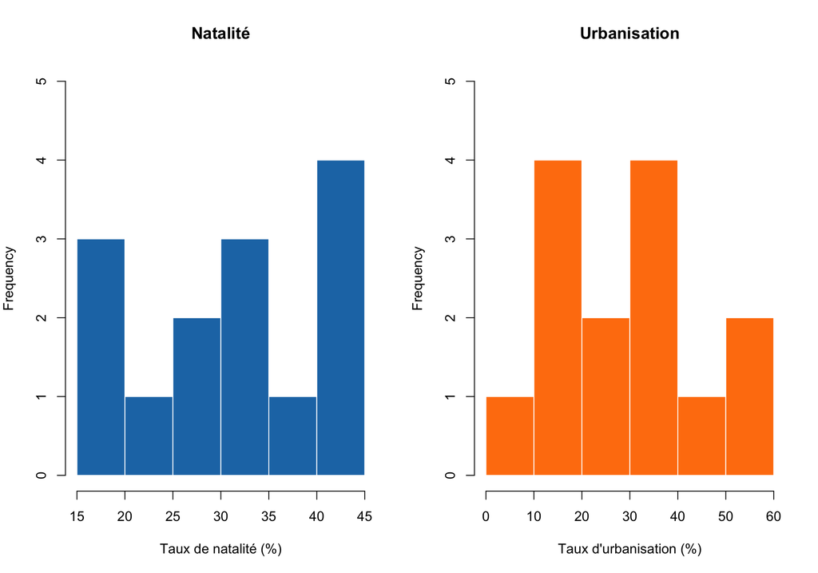

Histogrammes : Distribution des deux variables

```r
par(mfrow=c(1,2), mar=c(5,4,4,2))

hist(don$natalite,
     main="Natalité",
     xlab="Taux de natalité (%)",
     col="#1f77b4",
     border="white",
     breaks=7,
     ylim=c(0,5))

hist(don$urbanisation,
     main="Urbanisation",
     xlab="Taux d'urbanisation (%)",
     col="#ff7f0e",
     border="white",
     breaks=7,
     ylim=c(0,5))
```

```r
par(mfrow=c(1,1))
```

**📌 Interprétation :** Le taux de natalité affiche une distribution étalée (16% à 44%), tandis que l’urbanisation concentre ses valeurs entre 10% et 60%.

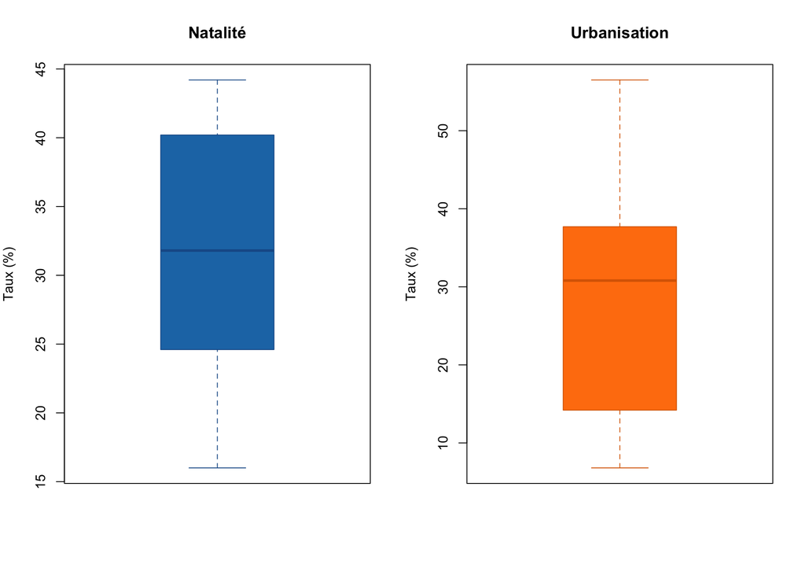

Boxplots : Analyse de la dispersion

```r
par(mfrow=c(1,2), mar=c(5,4,4,2))

boxplot(don$natalite,
        main="Natalité",
        ylab="Taux (%)",
        col="#1f77b4",
        border="#1a5a96")

boxplot(don$urbanisation,
        main="Urbanisation",
        ylab="Taux (%)",
        col="#ff7f0e",
        border="#d96600")
```

```r
par(mfrow=c(1,1))
```

**📌 Interprétation :** Dispersion modérée sans points aberrants. Les médianes avoisinent respectivement 32% et 30%.

# 3️⃣ Analyse bivariée et corrélation

## Test de corrélation

```r
# Calcul de la corrélation de Pearson
r_pearson <- cor(don$natalite, don$urbanisation, method="pearson")
test_cor  <- cor.test(don$natalite, don$urbanisation, method="pearson")

cat("╔══════════════════════════════════════════════════╗\n")
```

```
#> ╔══════════════════════════════════════════════════╗
```

```r
cat("║        ANALYSE DE CORRÉLATION PEARSON           ║\n")
```

```
#> ║        ANALYSE DE CORRÉLATION PEARSON           ║
```

```r
cat("╚══════════════════════════════════════════════════╝\n")
```

```
#> ╚══════════════════════════════════════════════════╝
```

```r
cat("  r (coefficient)     :", round(r_pearson,3), "\n")
```

```
#>   r (coefficient)     : -0.621
```

```r
cat("  p-value             :", format(test_cor$p.value, digits=4), "\n")
```

```
#>   p-value             : 0.01774
```

```r
cat("  IC 95%              : [", round(test_cor$conf.int[1],3), " ; ",
    round(test_cor$conf.int[2],3), "]\n")
```

```
#>   IC 95%              : [ -0.866  ;  -0.135 ]
```

**✓ Résultat clé :** Corrélation **négative et forte** (r = -0.621), statistiquement significative (p < 0.05).

## 📈 Nuage de points

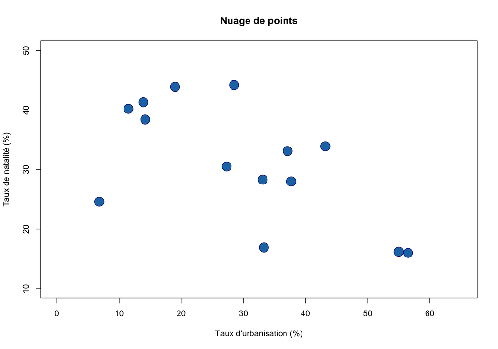

Relation bivariée : Natalité vs Urbanisation

```r
plot(
  don$urbanisation, don$natalite,
  main = "Nuage de points",
  pch = 21,
  bg = "#1f77b4",
  col = "#000080",
  cex = 2.5,
  xlab = "Taux d'urbanisation (%)",
  ylab = "Taux de natalité (%)",
  xlim = c(0, 65),
  ylim = c(10, 50)
)
```

# 4️⃣ Modèle de régression linéaire

## Ajustement du modèle

```r
# Création du modèle linéaire
mod_lin <- lm(natalite ~ urbanisation, data = don)

# Extraction des résultats
a <- coef(mod_lin)[1]
b <- coef(mod_lin)[2]
R2 <- summary(mod_lin)$r.squared
adj_R2 <- summary(mod_lin)$adj.r.squared
p_pente <- summary(mod_lin)$coefficients[2,4]

# Affichage formaté
cat("╔════════════════════════════════════════════════════╗\n")
```

```
#> ╔════════════════════════════════════════════════════╗
```

```r
cat("║       RÉSULTATS DE LA RÉGRESSION LINÉAIRE         ║\n")
```

```
#> ║       RÉSULTATS DE LA RÉGRESSION LINÉAIRE         ║
```

```r
cat("╚════════════════════════════════════════════════════╝\n\n")
```

```
#> ╚════════════════════════════════════════════════════╝
```

```r
# Résumé complet
summary(mod_lin)
```

```
#>
#> Call:
#> lm(formula = natalite ~ urbanisation, data = don)
#>
#> Residuals:
#>      Min       1Q   Median       3Q      Max
#> -15.6782  -3.7413   0.5601   4.6440  12.5772
#>
#> Coefficients:
#>              Estimate Std. Error t value Pr(>|t|)
#> (Intercept)   42.9905     4.8454   8.872 1.28e-06 ***
#> urbanisation  -0.3989     0.1453  -2.746   0.0177 *
#> ---
#> Signif. codes:  0 '***' 0.001 '**' 0.01 '*' 0.05 '.' 0.1 ' ' 1
#>
#> Residual standard error: 8.154 on 12 degrees of freedom
#> Multiple R-squared:  0.3859, Adjusted R-squared:  0.3347
#> F-statistic:  7.54 on 1 and 12 DF,  p-value: 0.01774
```

```r
cat("\n═══════════════════════════════════════════════════\n")
```

```
#>
#> ═══════════════════════════════════════════════════
```

```r
cat("  Équation :", round(a,3), "+", round(b,3), "× urbanisation\n")
```

```
#>   Équation : 42.991 + -0.399 × urbanisation
```

```r
cat("  R²       :", round(R2,3), "→", round(100*R2,1), "% variance expliquée\n")
```

```
#>   R²       : 0.386 → 38.6 % variance expliquée
```

```r
cat("  p-value  :", format(p_pente, digits=4), "\n")
```

```
#>   p-value  : 0.01774
```

```r
cat("═══════════════════════════════════════════════════\n")
```

```
#> ═══════════════════════════════════════════════════
```

## 📐 Visualisation de la régression

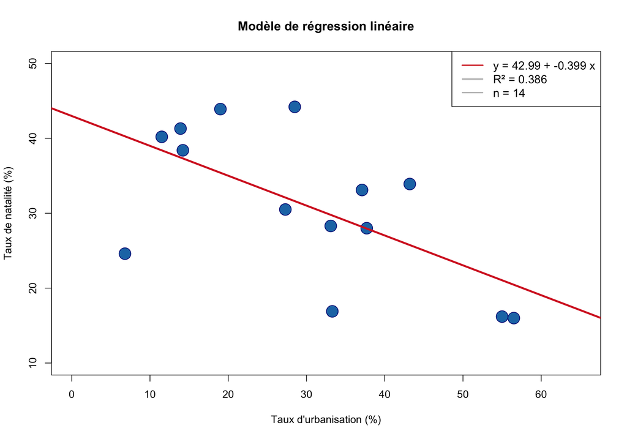

Droite de régression linéaire ajustée

```r
plot(don$urbanisation, don$natalite,
     pch=21,
     bg="#1f77b4",
     col="#000080",
     cex=2.5,
     xlab="Taux d'urbanisation (%)",
     ylab="Taux de natalité (%)",
     main="Modèle de régression linéaire",
     xlim=c(0, 65),
     ylim=c(10, 50))

# Droite de régression
abline(mod_lin, col="#d62728", lwd=3)

# Légende améliorée
legend("topright",
       legend=c(
         paste("y =", round(a,2), "+", round(b,3), "x"),
         paste("R² =", round(R2,3)),
         paste("n =", nrow(don))
       ),
       col=c("#d62728", "gray50", "gray50"),
       lwd=c(2, 1, 1),
       bty="round",
       bg="white",
       cex=1.1)
```

# 5️⃣ Diagnostics du modèle

## 🔍 Analyse des résidus

```r
# Extraction des résidus
residus <- residuals(mod_lin)
fites   <- fitted(mod_lin)

cat("╔══════════════════════════════════════════════╗\n")
```

```
#> ╔══════════════════════════════════════════════╗
```

```r
cat("║     ANALYSE DES RÉSIDUS DU MODÈLE           ║\n")
```

```
#> ║     ANALYSE DES RÉSIDUS DU MODÈLE           ║
```

```r
cat("╚══════════════════════════════════════════════╝\n\n")
```

```
#> ╚══════════════════════════════════════════════╝
```

```r
summary(residus)
```

```
#>     Min.  1st Qu.   Median     Mean  3rd Qu.     Max.
#> -15.6782  -3.7413   0.5601   0.0000   4.6440  12.5772
```

```r
cat("\n  Moyenne des résidus :", round(mean(residus), 8), "(≈ 0 ✓)\n")
```

```
#>
#>   Moyenne des résidus : 0 (≈ 0 ✓)
```

```r
cat("  Écart-type          :", round(sd(residus), 3), "\n")
```

```
#>   Écart-type          : 7.834
```

## Graphiques de diagnostic détaillés

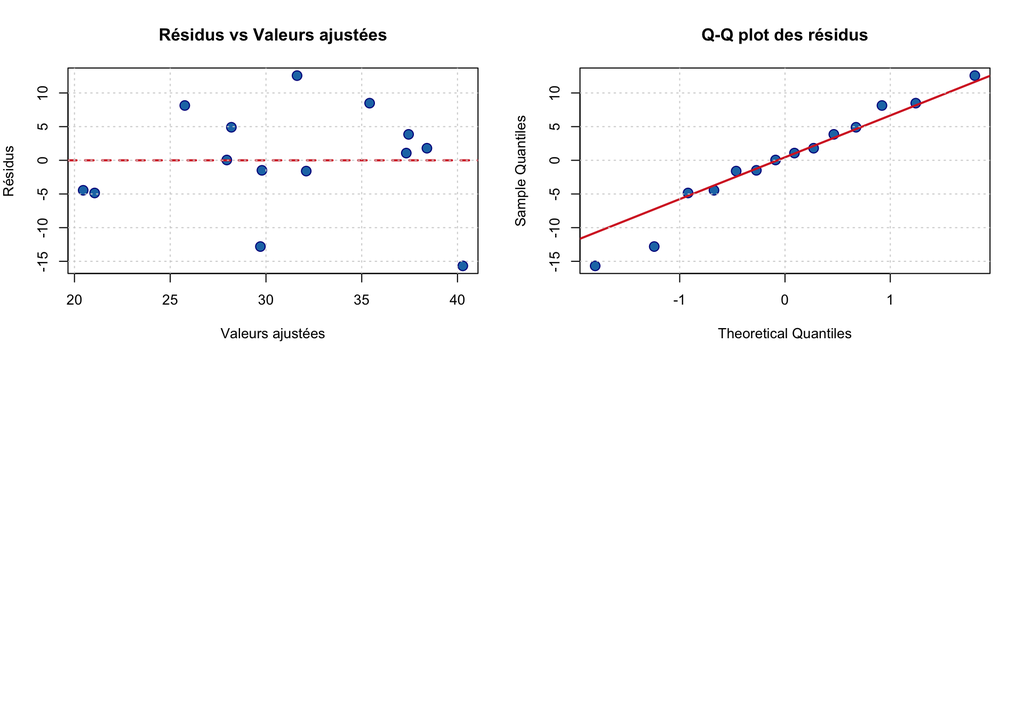

```r
par(mfrow=c(2,2), mar=c(5,4,4,2))

# 1. Résidus vs ajustées
plot(fites, residus,
     main="Résidus vs Valeurs ajustées",
     xlab="Valeurs ajustées",
     ylab="Résidus",
     pch=21,
     bg="#1f77b4",
     col="darkblue",
     cex=1.5)
abline(h=0, col="#d62728", lwd=2, lty=2)
grid()

# 2. Q-Q plot
qqnorm(residus,
       main="Q-Q plot des résidus",
       pch=21,
       bg="#1f77b4",
       col="darkblue",
       cex=1.5)
qqline(residus, col="#d62728", lwd=2)
grid()

par(mfrow=c(1,1))
```